# Data management

14-4-2021

## file management in general

[figure not shown]

http://phdcomics.com/comics.php?f=1531

## file management in general

[figure not shown]

PhD comics by Jorge Cham

## file management in general

[figure not shown]

Version control –> lesson 3

## Data management

[figure not shown]

file names true story

## FAIR data

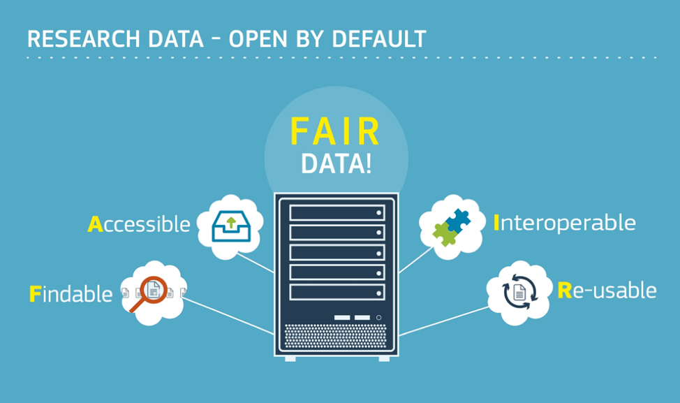

Europese commissie volgens mij

## Hoe dan?

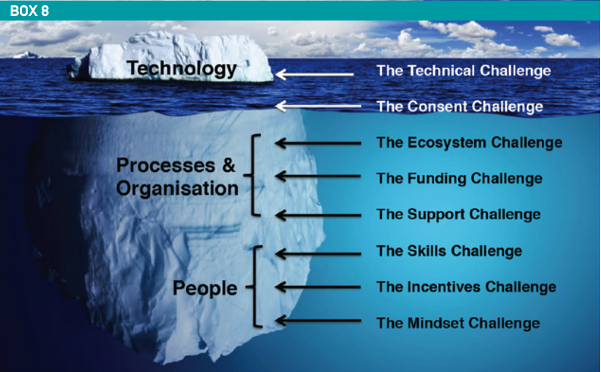

ICSU/IAP:TWAS/ISSC: it is not just a technology challenge. (Open data in a Big Data World, 2016)

## Les 2: data management

- identifiers
- data formats
- meta data
- folder structure
- Guerrilla Analytics Principles als kapstok

## Licensing

- net als alles wat je maakt kan je aan je data een kaartje hangen met uitleg over wat mensen er van jou wel en niet mee mogen doen.
  - commercial
  - creative commons
  - public domain

## creative commons

[figure not shown]

source unclear

## Metadata

Maar alleen de data is niet genoeg.

[figure not shown]

## Examples metadata:

- date experiment was done
- time of measurements
- who did the data collection
- who did the analysis
- who paid for the research
- etc etc

## Discuss metadata:

Stel je voor: we willen twee datasets combineren van twee instellingen die hetzelde experiment hebben uitgevoerd: A) Theme hospital B) bejaardentehuis Avondrood.

In het experiment werd getest of een bepaald medicijn ervoor zorgt dat mensen afvallen, in vergelijking met een placebo. Deelnemers zijn gewogen voor en na behandeling.

Welke metadata zou je willen hebben als je de datasets wilt combineren?

Denk aan details op experiment-niveau, niet deelnemer-niveau (dus bijvoorbeeld: wat was de dosis van het medicijn? Was dat op beide locaties hetzelfde?)

*(dank aan Ted Laderas voor de opdracht)*

## Les 2: have fun